# Amr Mohammad Soliman

This data set contains 113,937 loans with 81 variables on each loan, including loan amount, borrower rate (or interest rate), current loan status, borrower income, borrower employment status,and the latest payment information.

# Univariate Plots Section

## BorrowerAPR and BorrowerRate

#### Histogram

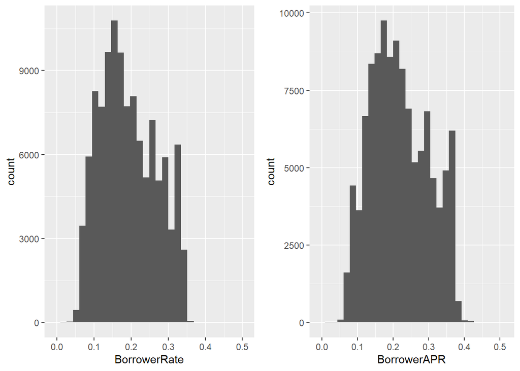

#### Boxplots

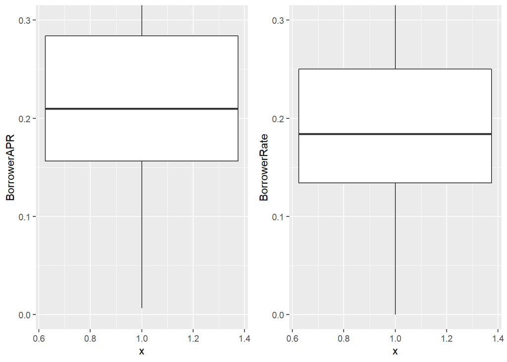

### Display the mean and range of the BorrowerRate

```
##    Min. 1st Qu.  Median    Mean 3rd Qu.    Max.
##  0.0000  0.1340  0.1840  0.1928  0.2500  0.4975
```

### Display the mean and range of the BorrowerAPR

```
##    Min. 1st Qu.  Median    Mean 3rd Qu.    Max.    NA's
## 0.00653 0.15629 0.20976 0.21883 0.28381 0.51229      25
```

The distribution of BorrowerAPR and BorrowerRate should be  
similar with slight difference since the APR is always  
higher than the interest rate.

## Employment status

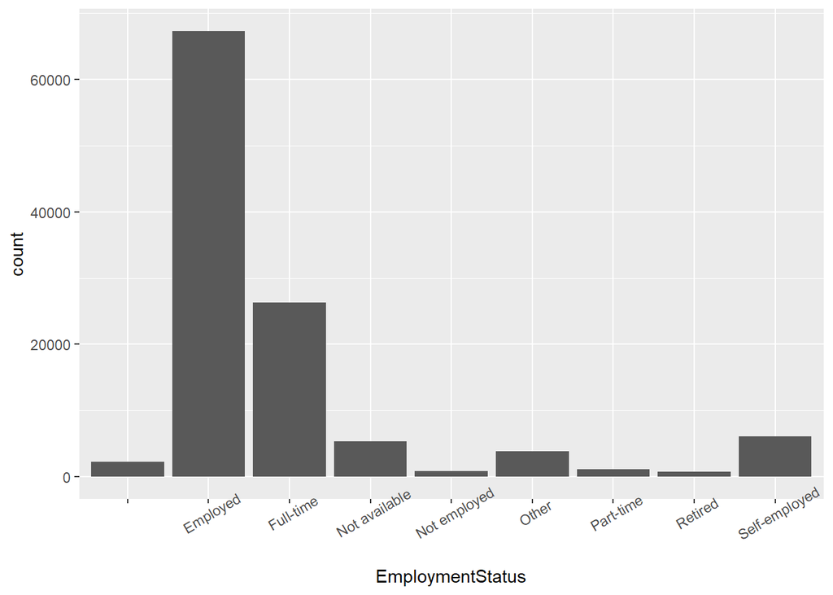

```
## pld$EmploymentStatus:
##    Min. 1st Qu.  Median    Mean 3rd Qu.    Max.
##  0.0000  0.1300  0.1780  0.1855  0.2375  0.4975
## --------------------------------------------------------
## pld$EmploymentStatus: Employed
##    Min. 1st Qu.  Median    Mean 3rd Qu.    Max.
##  0.0450  0.1359  0.1840  0.1928  0.2498  0.3600
## --------------------------------------------------------
## pld$EmploymentStatus: Full-time
##    Min. 1st Qu.  Median    Mean 3rd Qu.    Max.
##  0.0000  0.1200  0.1724  0.1870  0.2493  0.3600
## --------------------------------------------------------
## pld$EmploymentStatus: Not available
##    Min. 1st Qu.  Median    Mean 3rd Qu.    Max.
##  0.0000  0.1400  0.1900  0.1915  0.2500  0.3000
## --------------------------------------------------------
## pld$EmploymentStatus: Not employed
##    Min. 1st Qu.  Median    Mean 3rd Qu.    Max.
##  0.0100  0.1830  0.2599  0.2441  0.3134  0.3500
## --------------------------------------------------------
## pld$EmploymentStatus: Other
##    Min. 1st Qu.  Median    Mean 3rd Qu.    Max.
##  0.0565  0.1565  0.2099  0.2137  0.2712  0.3500
## --------------------------------------------------------
## pld$EmploymentStatus: Part-time
##    Min. 1st Qu.  Median    Mean 3rd Qu.    Max.
##  0.0100  0.1227  0.1690  0.1844  0.2399  0.3500
## --------------------------------------------------------
## pld$EmploymentStatus: Retired
##    Min. 1st Qu.  Median    Mean 3rd Qu.    Max.
##  0.0500  0.1202  0.1829  0.1944  0.2625  0.3500
## --------------------------------------------------------
## pld$EmploymentStatus: Self-employed
##    Min. 1st Qu.  Median    Mean 3rd Qu.    Max.
##  0.0100  0.1400  0.1899  0.2023  0.2695  0.3500
```

The vast majority of borrowers are Employed/ following by Full-time

## Income Range buckets

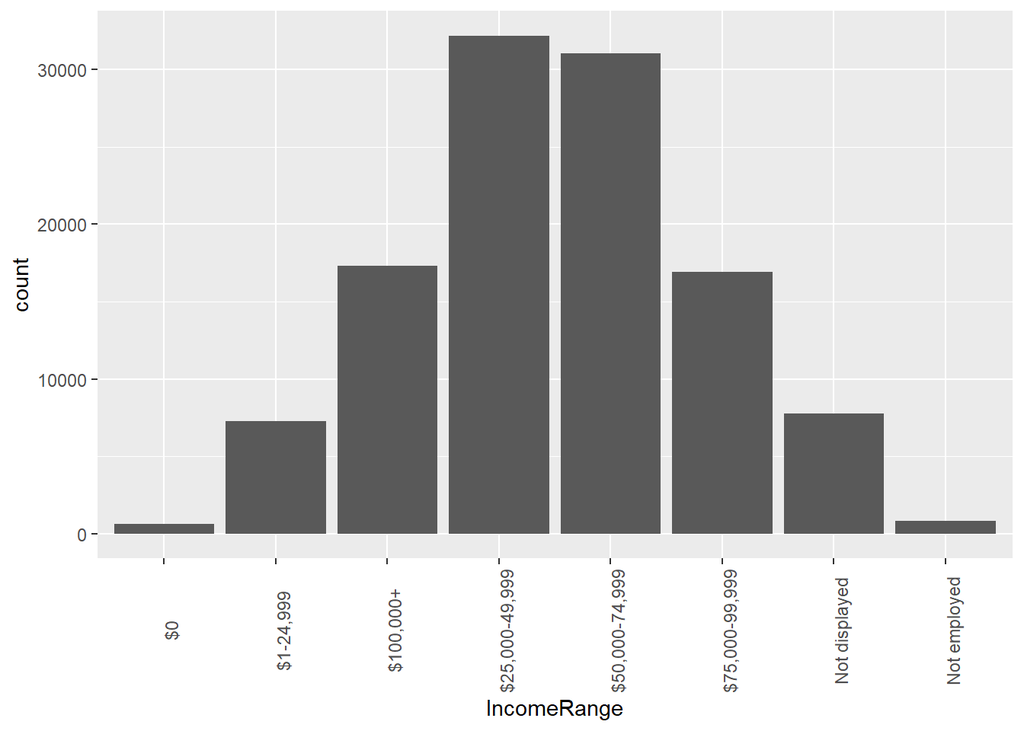

## Loan Status

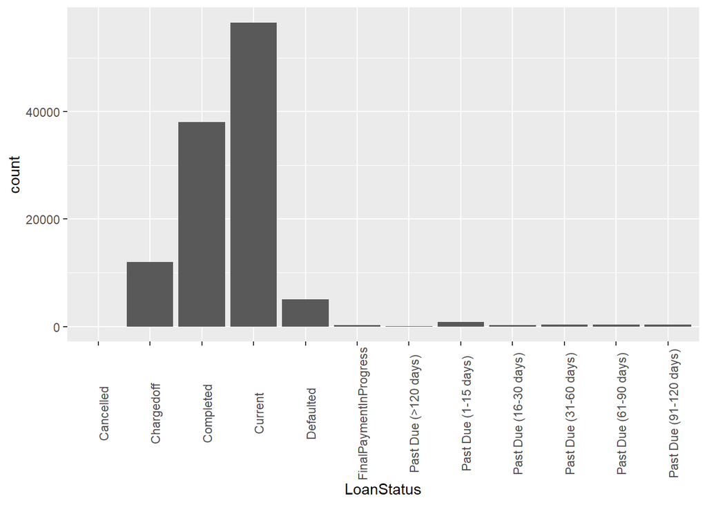

It appears that a large majority of loans are/ either Completed or Curren

## The Term to maturity for each loan

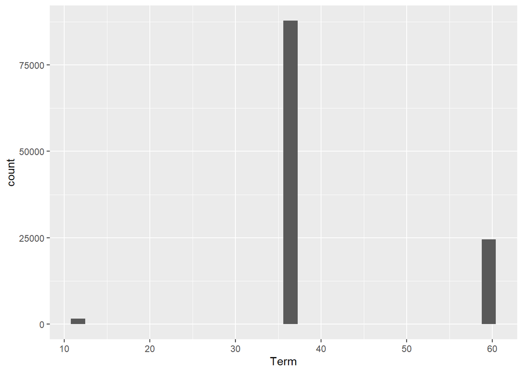

```
##    Min. 1st Qu.  Median    Mean 3rd Qu.    Max.
##   12.00   36.00   36.00   40.83   36.00   60.00
```

The majority of of loans are short term at 36 months.

## Histogram of Stated Monthly Income

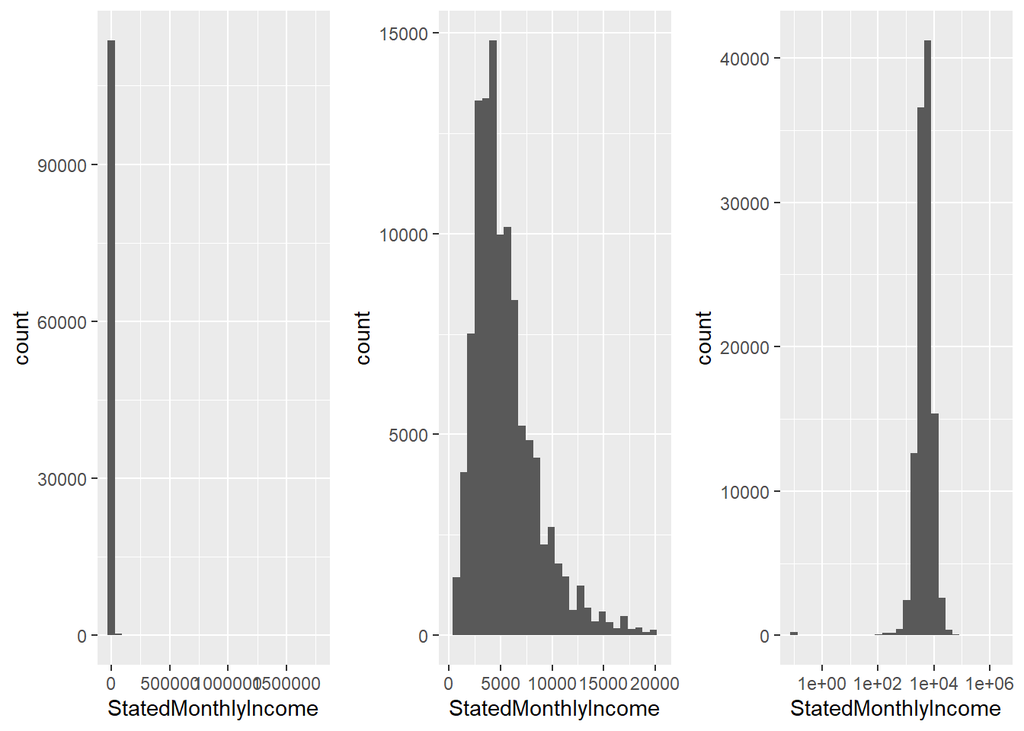

```
##    Min. 1st Qu.  Median    Mean 3rd Qu.    Max.
##       0    3200    4667    5608    6825 1750003
```

The histogram plot of the original data is highly right skewed.  
So I used summary function and find that the maximum  
value is 1750003, which is likely to be an error.  
So in the next 2 plots, I removed the top 1% data  
from the original and I used scale_x_log10 to get  
more reasonable plot.

## Histogram of the Debt To Income Ratio

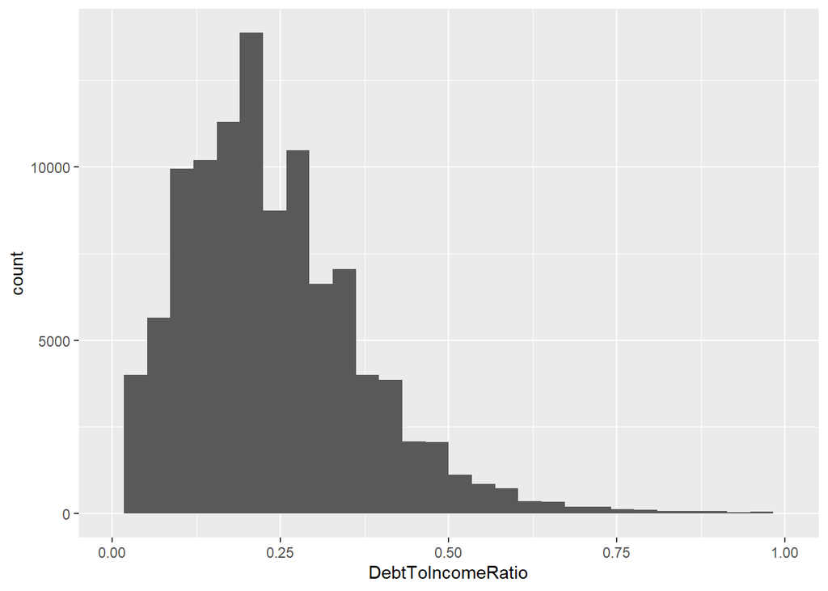

```
##    Min. 1st Qu.  Median    Mean 3rd Qu.    Max.    NA's
##   0.000   0.140   0.220   0.276   0.320  10.010    8554
```

The histogram is right skewed, after filtering the NA values  
and excluding the outliers.After using summary function,  
I find that the maximum value is 10.010  
,which is likely to be an error.

## Histogram of the Available Bank card Credit

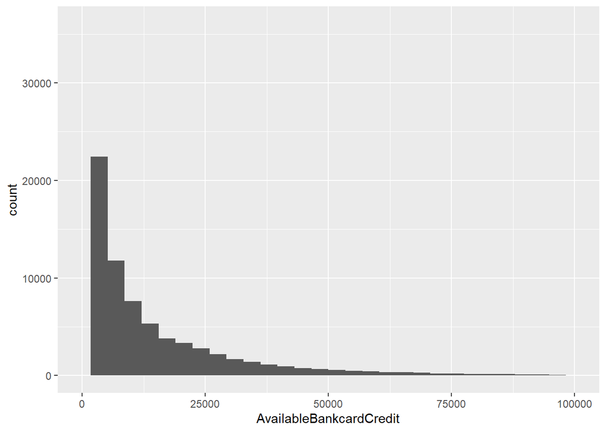

```
##    Min. 1st Qu.  Median    Mean 3rd Qu.    Max.    NA's
##       0     880    4100   11210   13180  646285    7544
```

Most of borrowers have low values of Available Bank card Credit

## BorrowerRate by credit grade

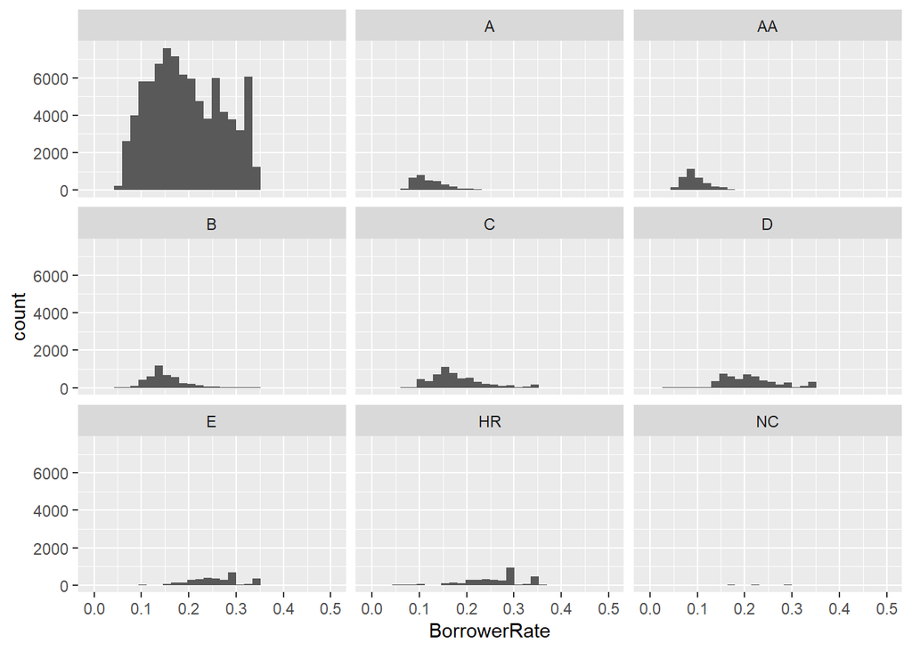

```
## pld$CreditGrade:
##    Min. 1st Qu.  Median    Mean 3rd Qu.    Max.
##  0.0400  0.1359  0.1875  0.1960  0.2574  0.3600
## --------------------------------------------------------
## pld$CreditGrade: A
##    Min. 1st Qu.  Median    Mean 3rd Qu.    Max.
##  0.0000  0.0970  0.1151  0.1251  0.1406  0.3500
## --------------------------------------------------------
## pld$CreditGrade: AA
##    Min. 1st Qu.  Median    Mean 3rd Qu.    Max.
## 0.00000 0.07740 0.08900 0.09806 0.11000 0.32380
## --------------------------------------------------------
## pld$CreditGrade: B
##    Min. 1st Qu.  Median    Mean 3rd Qu.    Max.
##  0.0001  0.1270  0.1428  0.1536  0.1708  0.3600
## --------------------------------------------------------
## pld$CreditGrade: C
##    Min. 1st Qu.  Median    Mean 3rd Qu.    Max.
##  0.0000  0.1425  0.1699  0.1797  0.2025  0.3575
## --------------------------------------------------------
## pld$CreditGrade: D
##    Min. 1st Qu.  Median    Mean 3rd Qu.    Max.
##  0.0000  0.1665  0.2000  0.2119  0.2400  0.3600
## --------------------------------------------------------
## pld$CreditGrade: E
##    Min. 1st Qu.  Median    Mean 3rd Qu.    Max.
##  0.0100  0.2200  0.2558  0.2558  0.2900  0.3750
## --------------------------------------------------------
## pld$CreditGrade: HR
##    Min. 1st Qu.  Median    Mean 3rd Qu.    Max.
##  0.0000  0.2197  0.2700  0.2555  0.2900  0.4975
## --------------------------------------------------------
## pld$CreditGrade: NC
##    Min. 1st Qu.  Median    Mean 3rd Qu.    Max.
##  0.0500  0.1775  0.2300  0.2224  0.2800  0.3295
```

## BorrowerState

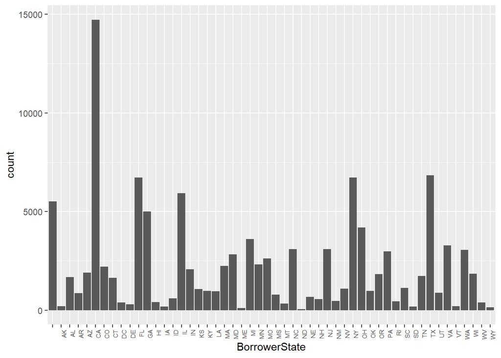

Most of borrowers are from CA

## Occupation

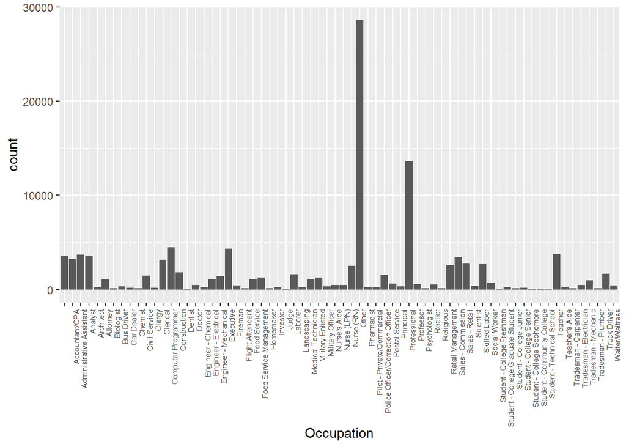

‘Other’ and ‘Professional’ stood out in the occupation chart. This shows that many borrowers decided to choose “other” and “professional” instead of their real occupation.

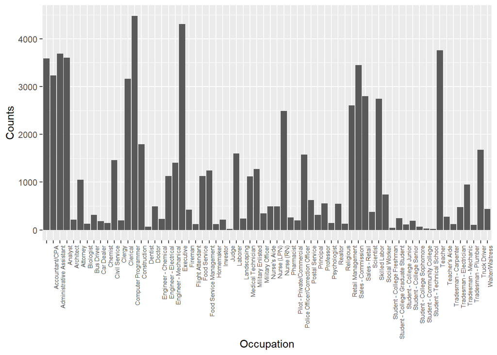

After removing the ‘Others’ and ‘Professional’ data, the top three occupations counts are ‘computer programmer’, ‘Excutives’, and ‘Teacher’.

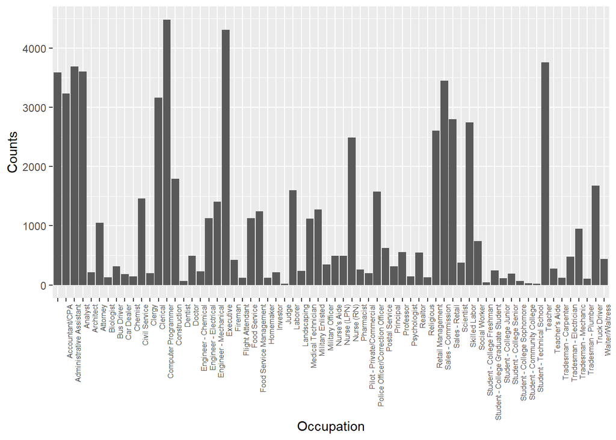

## BorrowRAte by IsBorrowerHomeowner

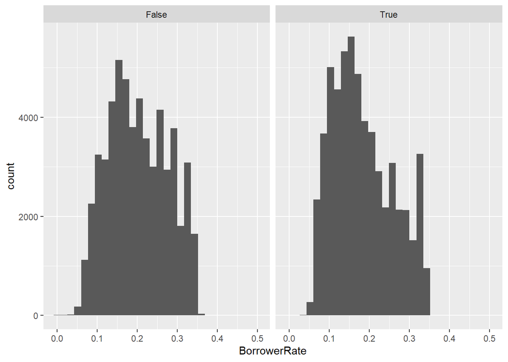

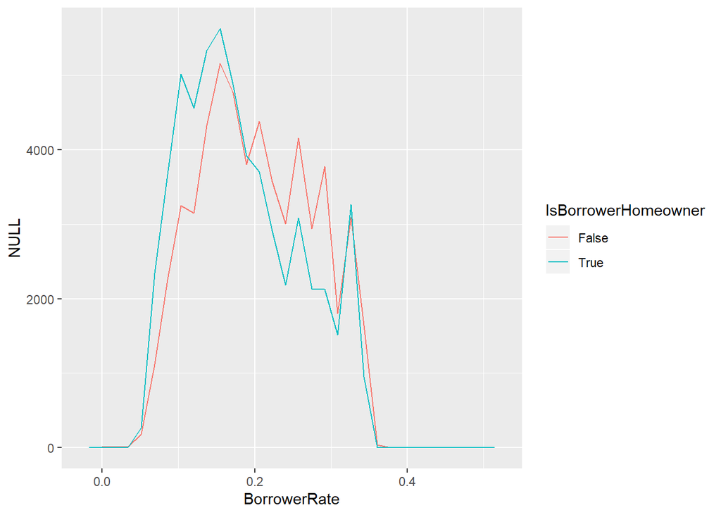

```
## pld$IsBorrowerHomeowner: False
##    Min. 1st Qu.  Median    Mean 3rd Qu.    Max.
##  0.0000  0.1449  0.1980  0.2029  0.2624  0.4975
## --------------------------------------------------------
## pld$IsBorrowerHomeowner: True
##    Min. 1st Qu.  Median    Mean 3rd Qu.    Max.
##  0.0000  0.1239  0.1700  0.1828  0.2394  0.3600
```

## BankCardUtilization

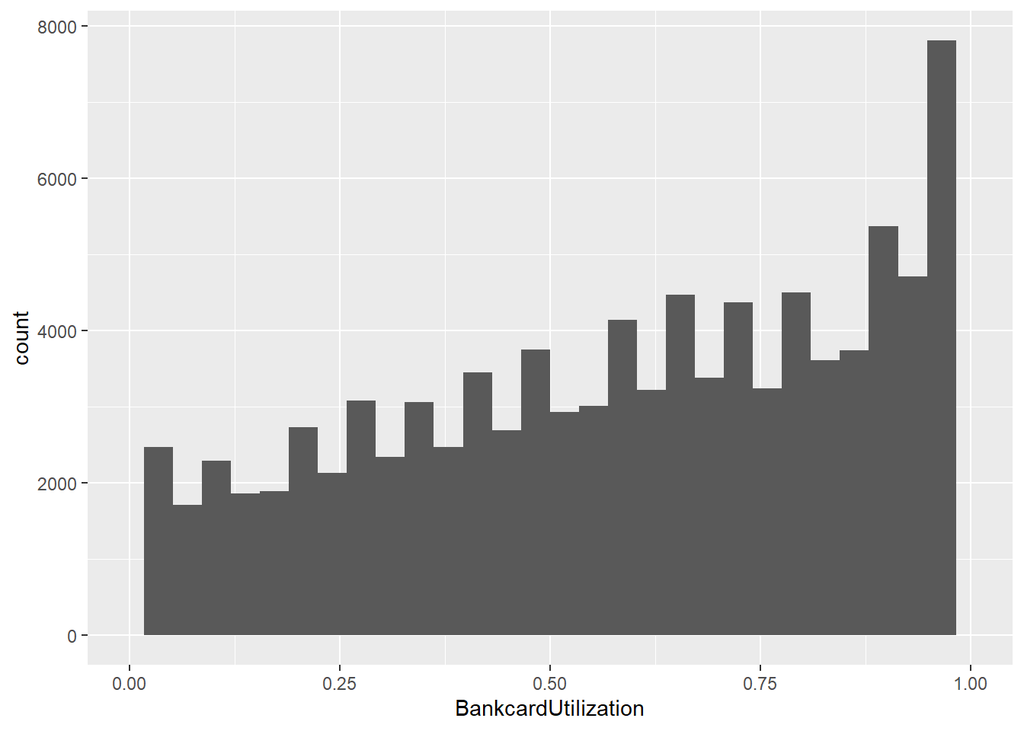

```
##    Min. 1st Qu.  Median    Mean 3rd Qu.    Max.    NA's
##   0.000   0.310   0.600   0.561   0.840   5.950    7604
```

Being left skewed makes sense, because most of the borrowers might have almost maxed out their credit limits

## Rating

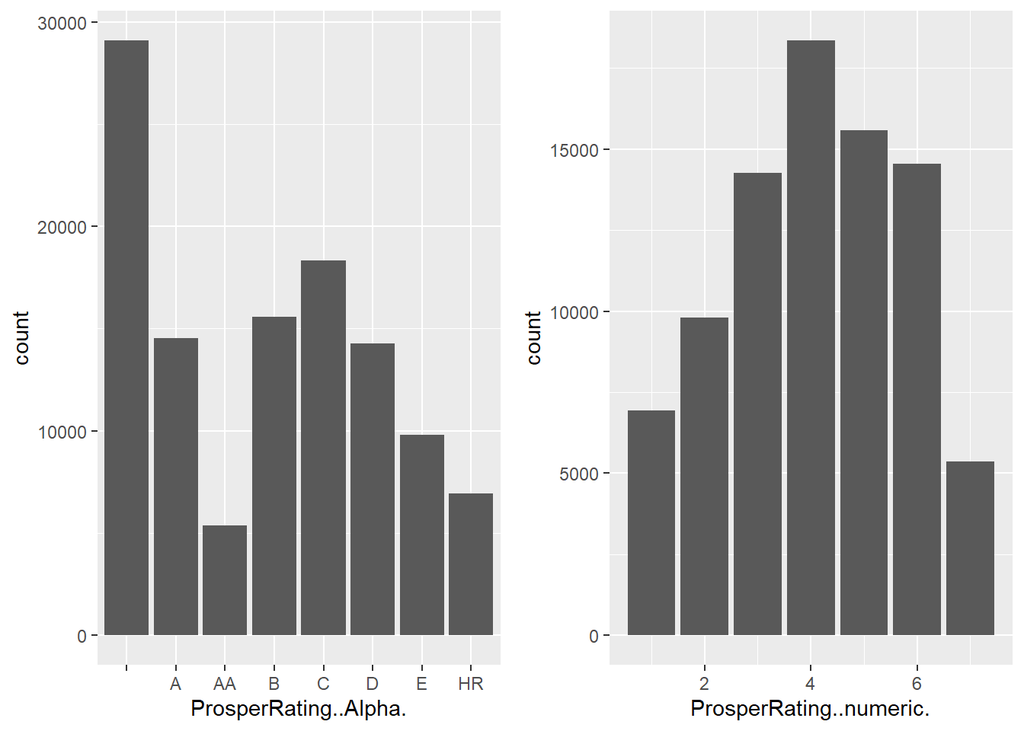

#### Summary of ProsperRating..Alpha.

```
##           A    AA     B     C     D     E    HR
## 29084 14551  5372 15581 18345 14274  9795  6935
```

#### Summary of ProsperRating..numeric.

```
##    Min. 1st Qu.  Median    Mean 3rd Qu.    Max.    NA's
##   1.000   3.000   4.000   4.072   5.000   7.000   29084
```

#### The mean of ProsperRating..numeric. for ProsperRating..Alpha.

```
## pld$ProsperRating..Alpha.:
## [1] NA
## --------------------------------------------------------
## pld$ProsperRating..Alpha.: A
## [1] 6
## --------------------------------------------------------
## pld$ProsperRating..Alpha.: AA
## [1] 7
## --------------------------------------------------------
## pld$ProsperRating..Alpha.: B
## [1] 5
## --------------------------------------------------------
## pld$ProsperRating..Alpha.: C
## [1] 4
## --------------------------------------------------------
## pld$ProsperRating..Alpha.: D
## [1] 3
## --------------------------------------------------------
## pld$ProsperRating..Alpha.: E
## [1] 2
## --------------------------------------------------------
## pld$ProsperRating..Alpha.: HR
## [1] 1
```

The most common rating is C(4) follows by B(5),  
A(6) and D(3).The most common of borrowers have  
rating (C) The highest rating (AA) has the lowest  
number of borrowers.

# Univariate Analysis

### What is the structure of your dataset?

```
## 'data.frame':    113937 obs. of  81 variables:
##  $ ListingKey                         : Factor w/ 113066 levels "00003546482094282EF90E5",..: 7180 7193 6647 6669 6686 6689 6699 6706 6687 6687 ...
##  $ ListingNumber                      : int  193129 1209647 81716 658116 909464 1074836 750899 768193 1023355 1023355 ...
##  $ ListingCreationDate                : Factor w/ 113064 levels "2005-11-09 20:44:28.847000000",..: 14184 111894 6429 64760 85967 100310 72556 74019 97834 97834 ...
##  $ CreditGrade                        : Factor w/ 9 levels "","A","AA","B",..: 5 1 8 1 1 1 1 1 1 1 ...
##  $ Term                               : int  36 36 36 36 36 60 36 36 36 36 ...
##  $ LoanStatus                         : Factor w/ 12 levels "Cancelled","Chargedoff",..: 3 4 3 4 4 4 4 4 4 4 ...
##  $ ClosedDate                         : Factor w/ 2803 levels "","2005-11-25 00:00:00",..: 1138 1 1263 1 1 1 1 1 1 1 ...
##  $ BorrowerAPR                        : num  0.165 0.12 0.283 0.125 0.246 ...
##  $ BorrowerRate                       : num  0.158 0.092 0.275 0.0974 0.2085 ...
##  $ LenderYield                        : num  0.138 0.082 0.24 0.0874 0.1985 ...
##  $ EstimatedEffectiveYield            : num  NA 0.0796 NA 0.0849 0.1832 ...
##  $ EstimatedLoss                      : num  NA 0.0249 NA 0.0249 0.0925 ...
##  $ EstimatedReturn                    : num  NA 0.0547 NA 0.06 0.0907 ...
##  $ ProsperRating..numeric.            : int  NA 6 NA 6 3 5 2 4 7 7 ...
```

[output cut: 67 more lines]

### What is/are the main feature(s) of interest in your dataset?

- BorrowerAPR
- BorrowerRate
- BorrowerState
- Employment status
- Income Range buckets
- Loan Status
- The Term
- Stated Monthly Income
- Debt To Income Ratio
- Available Bank card Credit
- Credit grade
- Occupation
- BankCardUtilization

### What other features in the dataset do you think will help support your

investigation into your feature(s) of interest?

- Employment Duration
- Loan Original Amount
- Investors
- Employment Status
- Prosper Rating

### Did you create any new variables from existing variables in the dataset?

No, I didn’t

### Of the features you investigated, were there any unusual distributions?

Did you perform any operations on the data to tidy, adjust, or change the form  
of the data? If so, why did you do this?

# Bivariate Plots Section

## Scatterplot Matrices

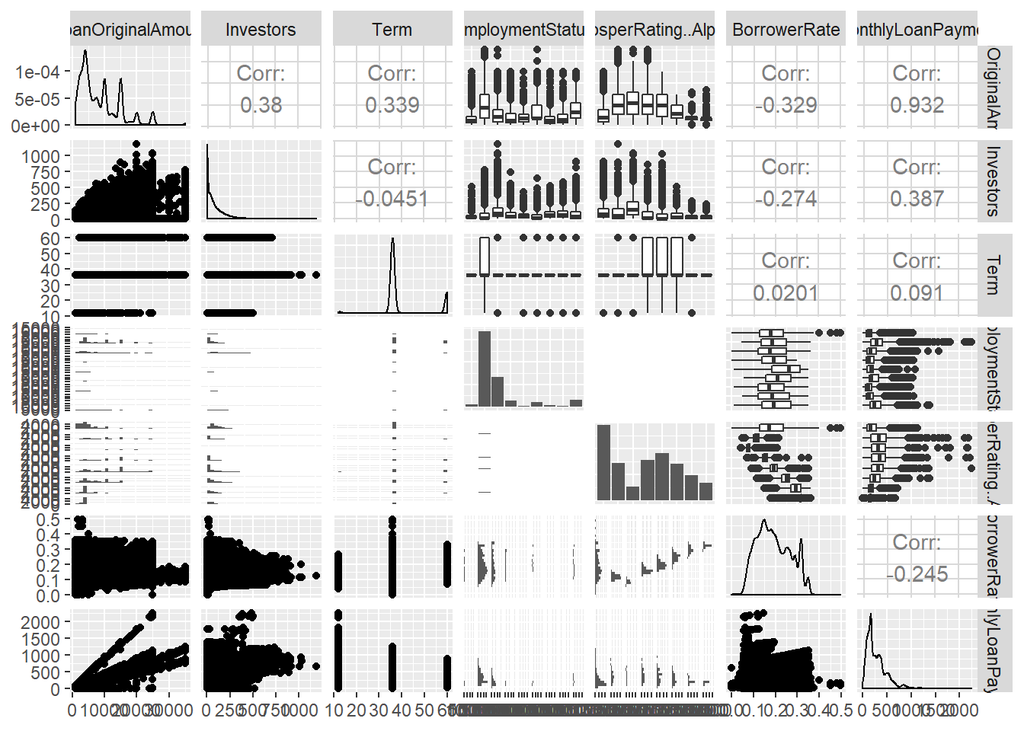

## The relationship between Loan Original Amount and Number of Investors

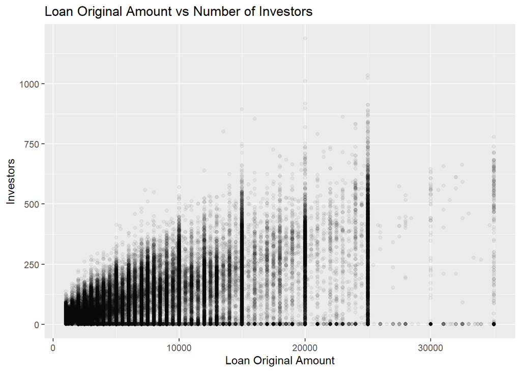

Larger loans have more investors

## Relationship between loan amount and terms.

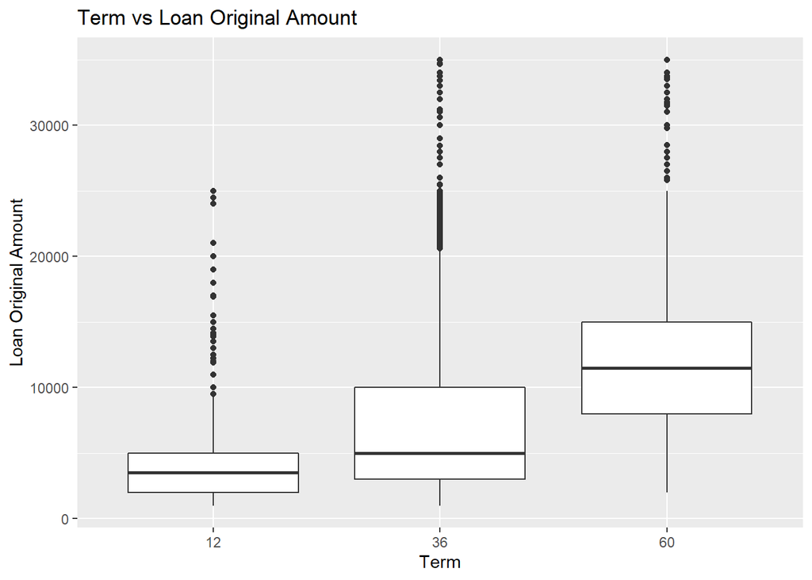

```
## pld$Term: 12
##    Min. 1st Qu.  Median    Mean 3rd Qu.    Max.
##    1000    2000    3500    4694    5000   25000
## --------------------------------------------------------
## pld$Term: 36
##    Min. 1st Qu.  Median    Mean 3rd Qu.    Max.
##    1000    3000    5000    7276   10000   35000
## --------------------------------------------------------
## pld$Term: 60
##    Min. 1st Qu.  Median    Mean 3rd Qu.    Max.
##    2000    8000   11500   12370   15000   35000
```

The loan amonts are getting larger with longer terms.

## Employment status and loan amount

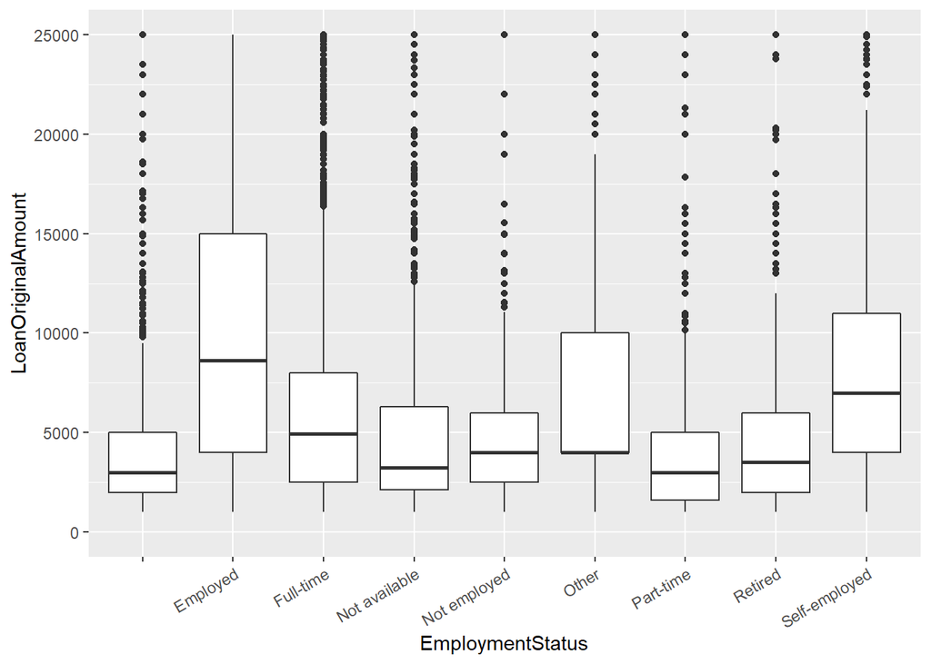

Employed people requested more loans and not employed people  
wanted more loan than part-time employed people

## Prosper Rating against borrower rate

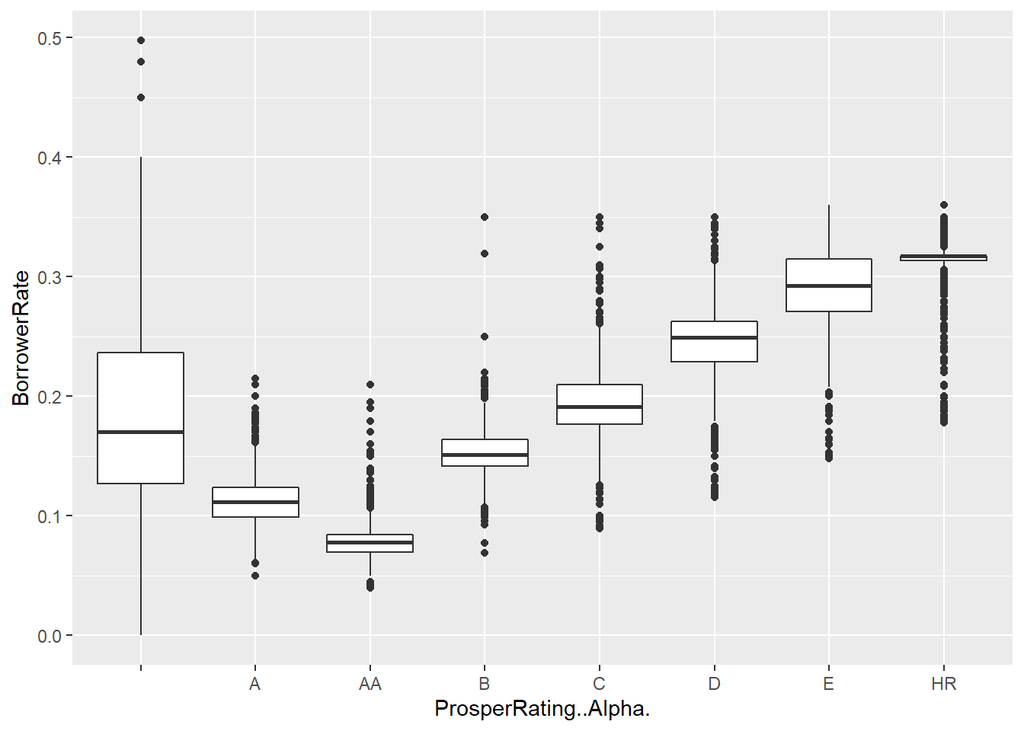

As we can see The better rating belongs to lower borrower rate.

## Relationship of term and borrower rate

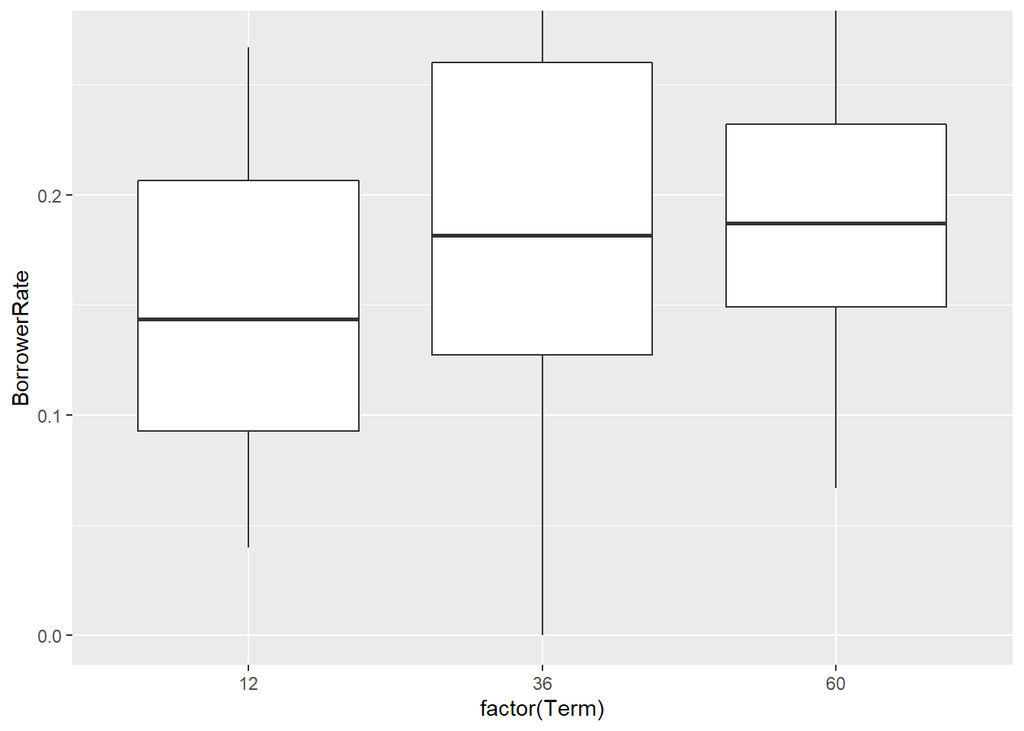

The median of 60 month term is the highest one,  
while the 12 month has the minimum one.

## MonthlyLoanPayment vs. Occupations

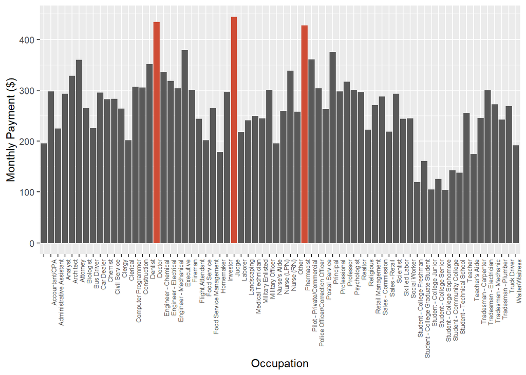

The top 3 occupations have high monthly loan payment are Judge,  
Doctor, and Pharmacist.The groups that have lower monthly loan payment are students.

# Bivariate Analysis

### Talk about some of the relationships you observed in this part of the

investigation. How did the feature(s) of interest vary with other features in  
the dataset?

### Did you observe any interesting relationships between the other features

(not the main feature(s) of interest)?

### What was the strongest relationship

you found?

# Multivariate Plots Section

## Scatterplot Matrices

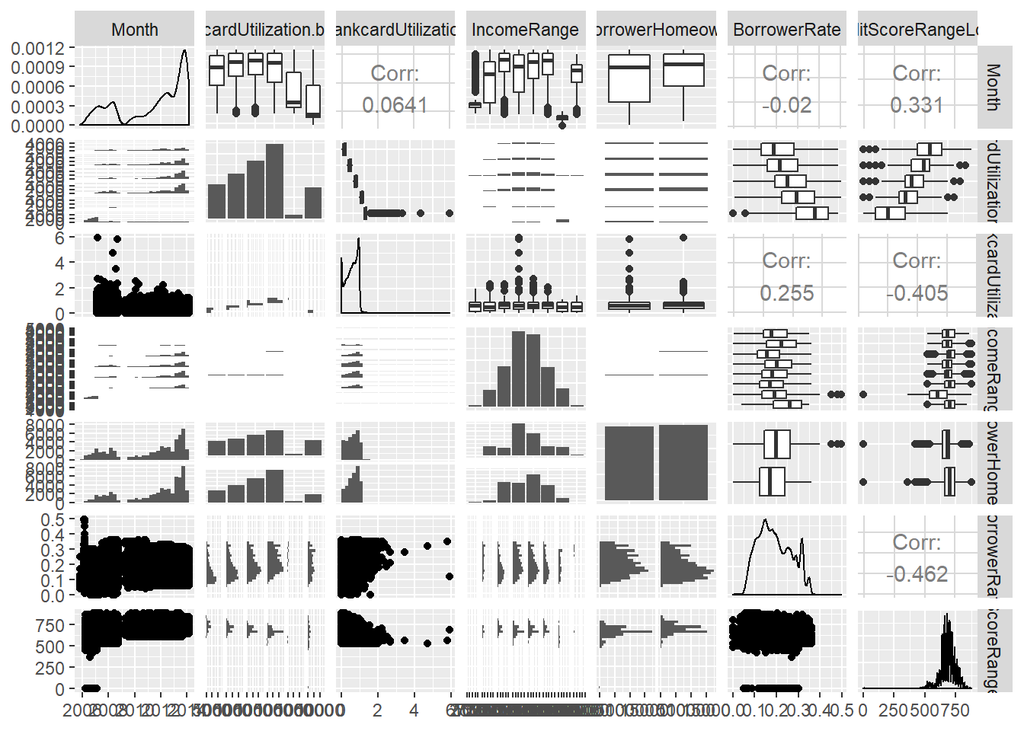

## Borrower Rate vs Income Range vs Is Borrower Homeowner

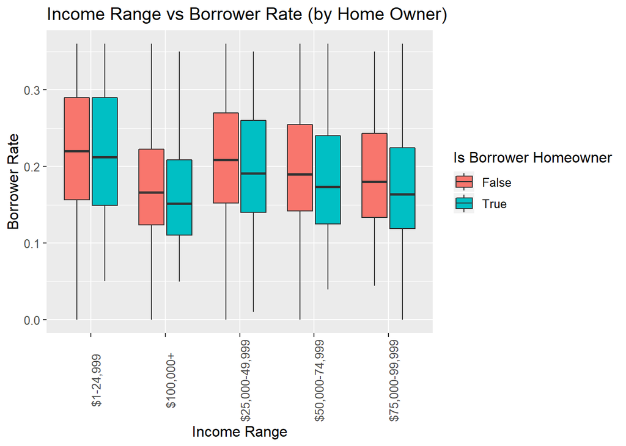

As we can see borrowers with higher income, who are home owners  
have lower borrower rates.

## Credit Scores vs Borrower rate vs Bankcard Utilization

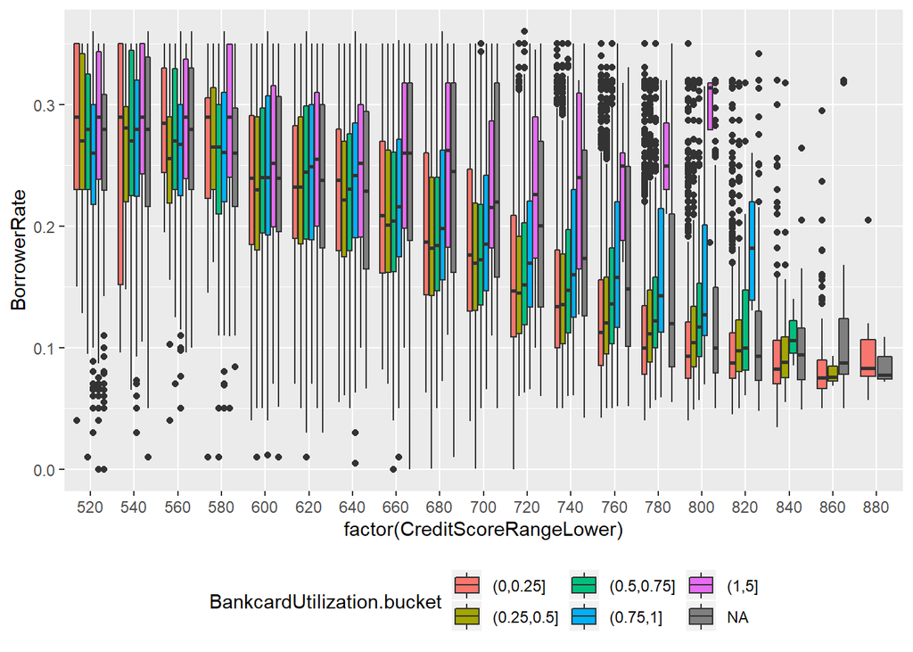

In general, a higher bankcard utilization rate corresponds  
with lower credit scores and higher interest rates.

## Interest Rate vs. Time vs. Homeowner

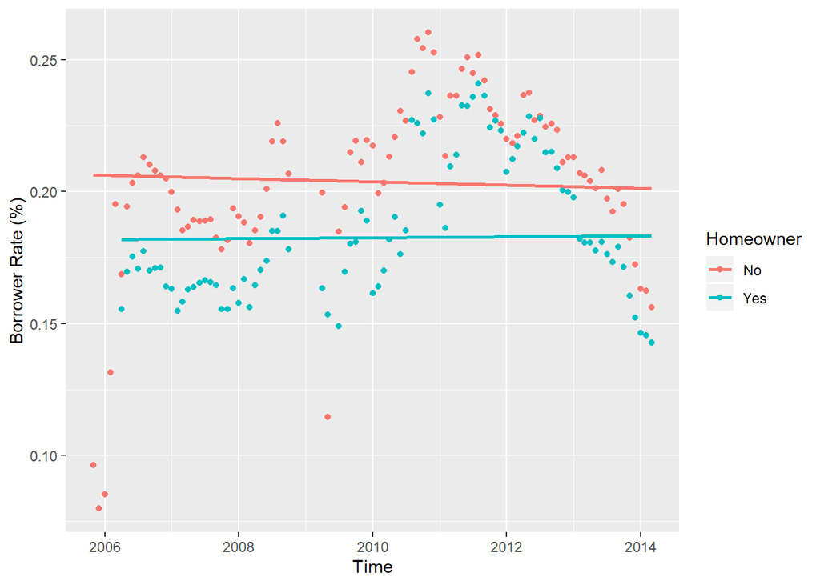

The interest rate for homeowners are generally lower  
than non-homeowners

## Relationship between Delinquencies and Employment Status

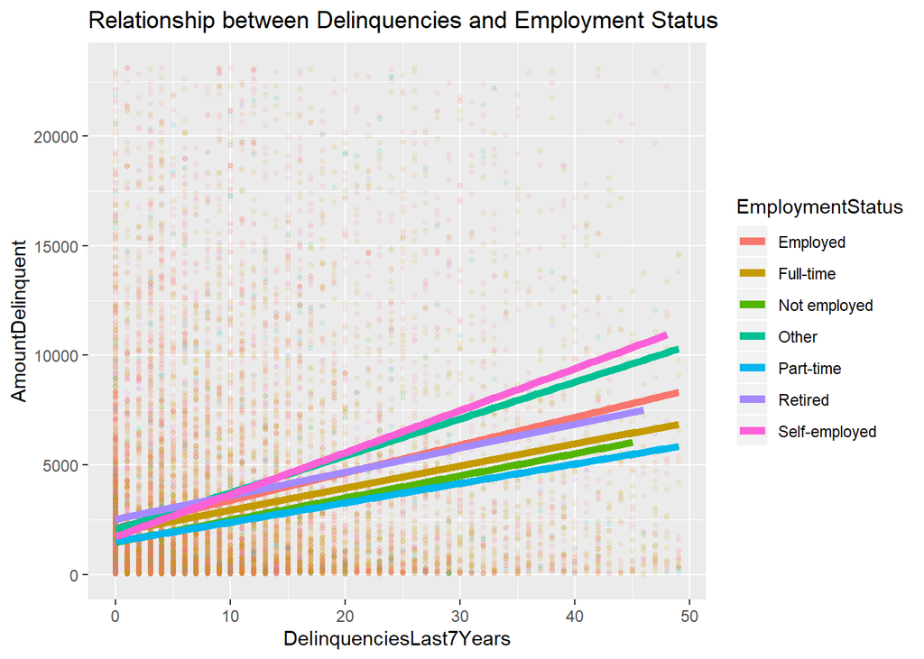

From the above we can see relationship between the  
amount borrowers were delinquent and the number of  
delinquencies they’ve had over the last 7 years then  
separated that by employment status.It is obvious that  
$Self-employed$ then $Other$ are the maximum.

# Multivariate Analysis

### Talk about some of the relationships you observed in this part of the

- Homeowners usually have lower risk of making defaulted loans since bank can use their house as collateral.
- A higher bankcard utilization rate corresponds with lower credit scores and higher interest rates.

### Were there any interesting or surprising interactions between features?

- I’ve observed that employed people are more likely to borrow money.

### OPTIONAL: Did you create any models with your dataset? Discuss the

strengths and limitations of your model. There was no need for any models ——

# Final Plots and Summary

### Plot One

##### Histogram of the Debt To Income Ratio

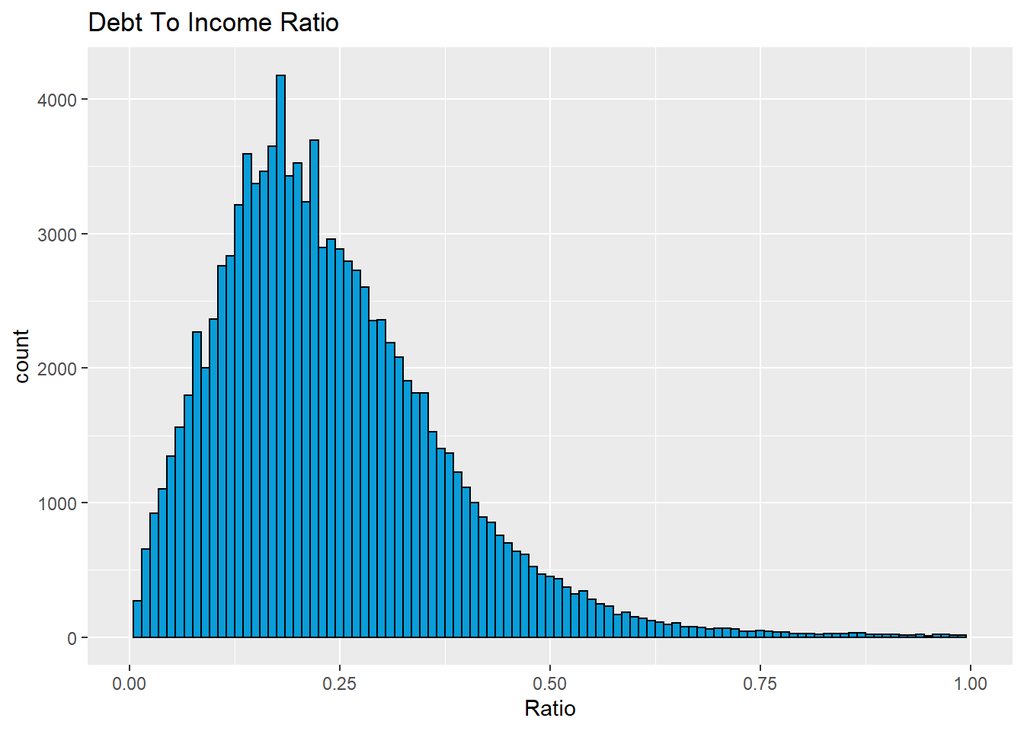

### Plot Two

##### MonthlyLoanPayment vs. Occupations

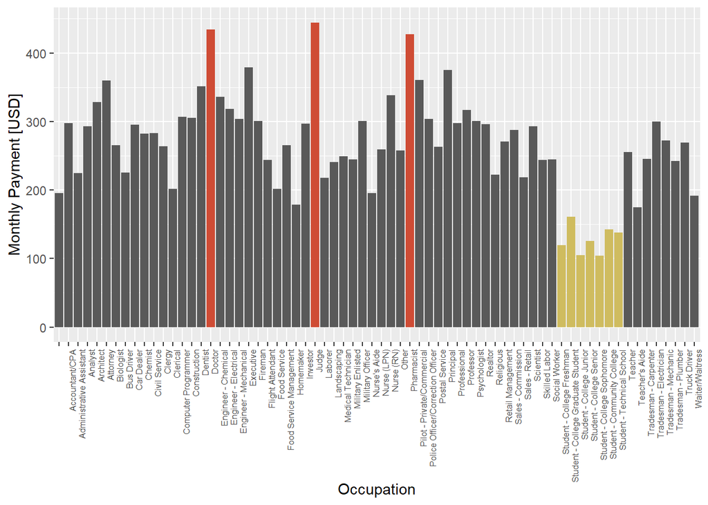

#### Description Two

The top 3 occupations have high monthly loan payment are $Judge$, $Doctor$,  
and $Pharmacist$.The monthly loan payment should be positively correlated  
with the salary.The top 3 listed occupations are all best-paying jobs  
according to [CNBC](http://www.cnbc.com/2016/07/26/the-25-highest-paying%20-jobs-in-america.\html), and the groups that have lower monthly loan payment are students.